# Projekt1

2024-04-03

```r
# Load required packages
library(ggplot2)
library(rmarkdown)
library(caret)
library(dplyr)
library(tidyr)
library(corrplot)
library(reshape2)
library(randomForest)
library(nnet)
library(knitr)
library(e1071)
library(ROCR)
```

## Dataset

The dataset represents 10 years (1999-2008) of clinical care at 130 US hospitals and integrated delivery networks. It includes over 50 features representing patient and hospital outcomes.

The data contains such attributes as patient number, race, gender, age, admission type, time in hospital, medical specialty of admitting physician, number of lab test performed, HbA1c test result, diagnosis, number of medication, diabetic medications, number of outpatient, inpatient, and emergency visits in the year before the hospitalization, etc.

```
https://api.openml.org/d/45069
```

```r
#Data loading from csv
df <- read.csv("./output.csv")
head(df)
```

```
##   admission_type_id discharge_disposition_id admission_source_id
## 1                 1                        3                   7
## 2                 5                        1                   1
## 3                 2                        1                   1
## 4                 3                        1                   1
## 5                 3                        1                   1
## 6                 6                        1                  17
##   time_in_hospital num_lab_procedures num_procedures num_medications
## 1                4                 41              2              17
## 2                3                 64              0              10
## 3                2                 39              0               8
## 4                1                 39              2              12
## 5                3                 21              2              23
## 6                3                 57              1              11
##   number_outpatient number_emergency number_inpatient number_diagnoses
```

[output cut: 55 more lines]

Target of the dataset is Class. It has information about the risk of readmision for diabetes patients. If they were hospitalized after more then 30, less then thirty days or never.

```r
#Basic statistics of the dataset
summary(df)
```

```
##  admission_type_id discharge_disposition_id admission_source_id
##  Min.   :1.000     Min.   : 1.000           Min.   : 1.000
##  1st Qu.:1.000     1st Qu.: 1.000           1st Qu.: 1.000
##  Median :1.000     Median : 1.000           Median : 7.000
##  Mean   :2.024     Mean   : 3.716           Mean   : 5.754
##  3rd Qu.:3.000     3rd Qu.: 4.000           3rd Qu.: 7.000
##  Max.   :8.000     Max.   :28.000           Max.   :25.000
##  time_in_hospital num_lab_procedures num_procedures num_medications
##  Min.   : 1.000   Min.   :  1.0      Min.   :0.00   Min.   : 1.00
##  1st Qu.: 2.000   1st Qu.: 31.0      1st Qu.:0.00   1st Qu.:10.00
##  Median : 4.000   Median : 44.0      Median :1.00   Median :15.00
##  Mean   : 4.396   Mean   : 43.1      Mean   :1.34   Mean   :16.02
##  3rd Qu.: 6.000   3rd Qu.: 57.0      3rd Qu.:2.00   3rd Qu.:20.00
##  Max.   :14.000   Max.   :132.0      Max.   :6.00   Max.   :81.00
##  number_outpatient number_emergency  number_inpatient  number_diagnoses
##  Min.   : 0.0000   Min.   : 0.0000   Min.   : 0.0000   Min.   : 1.000
##  1st Qu.: 0.0000   1st Qu.: 0.0000   1st Qu.: 0.0000   1st Qu.: 6.000
##  Median : 0.0000   Median : 0.0000   Median : 0.0000   Median : 8.000
##  Mean   : 0.3694   Mean   : 0.1978   Mean   : 0.6356   Mean   : 7.423
##  3rd Qu.: 0.0000   3rd Qu.: 0.0000   3rd Qu.: 1.0000   3rd Qu.: 9.000
##  Max.   :42.0000   Max.   :76.0000   Max.   :21.0000   Max.   :16.000
##      race              gender              age               weight
##  Length:101765      Length:101765      Length:101765      Length:101765
##  Class :character   Class :character   Class :character   Class :character
##  Mode  :character   Mode  :character   Mode  :character   Mode  :character
##
##
##
##   payer_code        medical_specialty     diag_1             diag_2
##  Length:101765      Length:101765      Length:101765      Length:101765
##  Class :character   Class :character   Class :character   Class :character
##  Mode  :character   Mode  :character   Mode  :character   Mode  :character
##
##
##
##     diag_3          max_glu_serum       A1Cresult          metformin
##  Length:101765      Length:101765      Length:101765      Length:101765
##  Class :character   Class :character   Class :character   Class :character
##  Mode  :character   Mode  :character   Mode  :character   Mode  :character
##
```

[output cut: 36 more lines]

```
##
##  glimepiride.pioglitazone metformin.rosiglitazone metformin.pioglitazone
##  Length:101765            Length:101765           Length:101765
##  Class :character         Class :character        Class :character
##  Mode  :character         Mode  :character        Mode  :character
##
##
##
##     change          diabetesMed           class
##  Length:101765      Length:101765      Length:101765
##  Class :character   Class :character   Class :character
##  Mode  :character   Mode  :character   Mode  :character
##
##
##
```

The Dataset provides a overview of patient information, including demographic details, medical history, hospital visits, diagnostic codes, and medication records.

```r
non_numeric_columns <- df[, sapply(df, function(x) !is.numeric(x))]
```

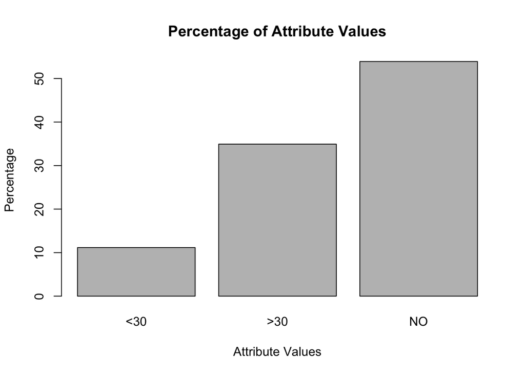

```r
# Plotting percentage of attribute values
attribute_value_percentages <- prop.table(table(df$class)) * 100

# Plot the percentages
barplot(attribute_value_percentages, xlab='Attribute Values', ylab='Percentage', main='Percentage of Attribute Values')
```

To deal with class imbalance and to better the accuracy we decided to merge the two classes of after how many days patients returned to hospital. We also merged it so we could use binary classification

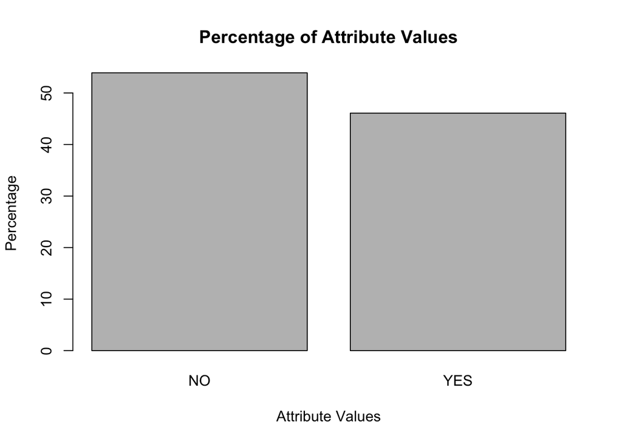

```r
df$class <- ifelse(df$class == "<30" | df$class == ">30", "YES", df$class)
# Plotting percentage of attribute values
attribute_value_percentages <- prop.table(table(df$class)) * 100

# Plot the percentages
barplot(attribute_value_percentages, xlab='Attribute Values', ylab='Percentage', main='Percentage of Attribute Values')
```

After examining data and missing values we decided to drop features **weight** as it has more then 96% missing and it would be too difficult to try to replace the missing values. We also dropped columns **payer_code** and **medical_specialty** as they also have high percentage of missing values and they are not important to predicting patient rehospitalization risk.

```r
df[df == ""] <- NA
# Missing values information
missing_values <- colSums(is.na(df))
present_values <- colSums(!is.na(df))

missing_percentage <- (missing_values / nrow(df)) * 100

# Create a data frame containing columns for missing values, present values, and missing percentage
missing_info_df <- data.frame(Missing_Values = missing_values,
                              Present_Values = present_values,
                              Missing_Percentage = missing_percentage)

# Sort the data frame by the "Missing Percentage" column in descending order
missing_info_df_sorted <- missing_info_df[order(-missing_info_df$Missing_Percentage), ]

(head(missing_info_df_sorted, 10))
```

```
##                          Missing_Values Present_Values Missing_Percentage
## weight                            98568           3197        96.85844839
## medical_specialty                 49948          51817        49.08170786
## payer_code                        40256          61509        39.55780475
## race                               2273          99492         2.23357736
## diag_3                             1423         100342         1.39831966
## diag_2                              358         101407         0.35179089
## diag_1                               21         101744         0.02063578
## admission_type_id                     0         101765         0.00000000
## discharge_disposition_id              0         101765         0.00000000
## admission_source_id                   0         101765         0.00000000
```

```r
#Finding out what kind of atributes is medical_speciality
unique_values <- unique(df$medical_specialty)
print(unique_values)
```

```
##  [1] NA
##  [2] "Surgery-Vascular"
##  [3] "InternalMedicine"
##  [4] "Surgery-General"
##  [5] "Family/GeneralPractice"
##  [6] "ObstetricsandGynecology"
##  [7] "Psychiatry"
##  [8] "Otolaryngology"
##  [9] "Orthopedics"
## [10] "Cardiology"
## [11] "Emergency/Trauma"
## [12] "Radiologist"
## [13] "PhysicalMedicineandRehabilitation"
## [14] "Neurology"
## [15] "Pulmonology"
```

[output cut: 58 more lines]

```r
columns_to_drop <- c('weight', 'medical_specialty', 'payer_code')
df <- df[, !names(df) %in% columns_to_drop]
```

We also decided to drop rows, where there was a missing value because we have a large dataset (101766 rows) and deleting about 4000 thousand rows won’t make difference in the result prediction.

```r
missing_rows <- rowSums(is.na(df))
cat("Number of rows with missing values:", sum(missing_rows))
```

```
## Number of rows with missing values: 4075
```

```r
df <- na.omit(df)
```

```r
unique(df$number_emergency)
```

```
##  [1]  0  1  2  3  5 13  9  4  7 16 11 22  6 29  8 12 15 10 25 14 54 21 19 28 18
## [26] 76 42 20 37 46 24 63 64
```

```r
# Function to detect and replace outliers with median
detect_replace_outliers <- function(x) {
  # Calculate the first and third quartiles
  Q1 <- quantile(x, 0.25)
  Q3 <- quantile(x, 0.75)

  # Calculate the interquartile range (IQR)
  IQR <- Q3 - Q1

  # Define lower and upper bounds for outliers detection
  lower_bound <- Q1 - 1.5 * IQR
  upper_bound <- Q3 + 1.5 * IQR

  # Detect outliers
  outliers <- x < lower_bound | x > upper_bound

  # Replace outliers with median
  x[outliers] <- median(x, na.rm = TRUE)

  return(x)
}

# Apply outlier detection and replacement to numerical columns
numeric_columns <- df[, sapply(colnames(df), function(x) is.numeric(df[[x]]) && !grepl("number_emergency", x))]


df[, names(numeric_columns)] <- lapply(numeric_columns, detect_replace_outliers)

# Check the data after outlier detection and replacement
head(df)
```

```
##   admission_type_id discharge_disposition_id admission_source_id
## 1                 1                        3                   7
## 2                 5                        1                   1
## 4                 3                        1                   1
## 5                 3                        1                   1
## 6                 6                        1                   7
## 7                 1                        1                   7
##   time_in_hospital num_lab_procedures num_procedures num_medications
## 1                4                 41              2              17
## 2                3                 64              0              10
## 4                1                 39              2              12
## 5                3                 21              2              23
## 6                3                 57              1              11
## 7                5                 55              4              26
##   number_outpatient number_emergency number_inpatient number_diagnoses
```

[output cut: 48 more lines]

```r
unique(df$number_emergency)
```

```
##  [1]  0  1  2  3  5 13  9  4  7 16 11 22  6 29  8 12 15 10 25 14 54 21 19 28 18
## [26] 76 42 20 37 46 24 63 64
```

On numerical data we decided to use Min-MAx Scaling to ensure that all numeric features are on a similar scale, which can be beneficial for machine learning algorithms and data visualization.

```r
unique(df$number_emergency)
```

```
##  [1]  0  1  2  3  5 13  9  4  7 16 11 22  6 29  8 12 15 10 25 14 54 21 19 28 18
## [26] 76 42 20 37 46 24 63 64
```

```r
# Perform Min-Max scaling for numeric columns
normalize <- function(x) {
  if (all(is.na(x)) || any(is.na(x))) {
    return(x)  # Return the original vector if it contains any NA values
  } else if (length(unique(x)) == 1) {
    return(rep(0, length(x)))   # Return 0 if all values are identical
  } else {
    return((x - min(x)) / (max(x) - min(x)))
  }
}

# Apply normalization to numeric columns
numeric_columns <- df[, sapply(df, is.numeric)]

# Normalize numeric columns
df[, names(numeric_columns)] <- lapply(numeric_columns, normalize)

# Check the normalized data
head(df)
```

```
##   admission_type_id discharge_disposition_id admission_source_id
## 1               0.0                0.2857143           0.4615385
## 2               0.8                0.0000000           0.0000000
## 4               0.4                0.0000000           0.0000000
## 5               0.4                0.0000000           0.0000000
## 6               1.0                0.0000000           0.4615385
## 7               0.0                0.0000000           0.4615385
##   time_in_hospital num_lab_procedures num_procedures num_medications
## 1        0.2727273          0.4210526            0.4         0.50000
## 2        0.1818182          0.6631579            0.0         0.28125
## 4        0.0000000          0.4000000            0.4         0.34375
## 5        0.1818182          0.2105263            0.4         0.68750
## 6        0.1818182          0.5894737            0.2         0.31250
## 7        0.3636364          0.5684211            0.8         0.78125
##   number_outpatient number_emergency number_inpatient number_diagnoses
```

[output cut: 48 more lines]

```r
unique(df$number_emergency)
```

```
##  [1] 0.00000000 0.01315789 0.02631579 0.03947368 0.06578947 0.17105263
##  [7] 0.11842105 0.05263158 0.09210526 0.21052632 0.14473684 0.28947368
## [13] 0.07894737 0.38157895 0.10526316 0.15789474 0.19736842 0.13157895
## [19] 0.32894737 0.18421053 0.71052632 0.27631579 0.25000000 0.36842105
## [25] 0.23684211 1.00000000 0.55263158 0.26315789 0.48684211 0.60526316
## [31] 0.31578947 0.82894737 0.84210526
```

The nonumerical values we decided to transform with label encoding to convert categorical values into numerical representations. Label encoding preserves the ordinal relationship between categories, making it suitable for ordinal categorical variables.

```r
# Identify columns with non-numeric values
non_numeric_columns <- df[, sapply(df, function(x) !is.numeric(x))]

# Perform label encoding for each non-numeric column
for (col in colnames(non_numeric_columns)) {
  df[[col]] <- as.numeric(factor(df[[col]]))
}

# Check the data types of columns after label encoding
head(df)
```

```
##   admission_type_id discharge_disposition_id admission_source_id
## 1               0.0                0.2857143           0.4615385
## 2               0.8                0.0000000           0.0000000
## 4               0.4                0.0000000           0.0000000
## 5               0.4                0.0000000           0.0000000
## 6               1.0                0.0000000           0.4615385
## 7               0.0                0.0000000           0.4615385
##   time_in_hospital num_lab_procedures num_procedures num_medications
## 1        0.2727273          0.4210526            0.4         0.50000
## 2        0.1818182          0.6631579            0.0         0.28125
## 4        0.0000000          0.4000000            0.4         0.34375
## 5        0.1818182          0.2105263            0.4         0.68750
## 6        0.1818182          0.5894737            0.2         0.31250
## 7        0.3636364          0.5684211            0.8         0.78125
##   number_outpatient number_emergency number_inpatient number_diagnoses race
```

[output cut: 48 more lines]

For making classification model we first decided to check the correlation between the features to choose the most significant ones.

```r
corr_mat <- round(cor(df), 2)
```

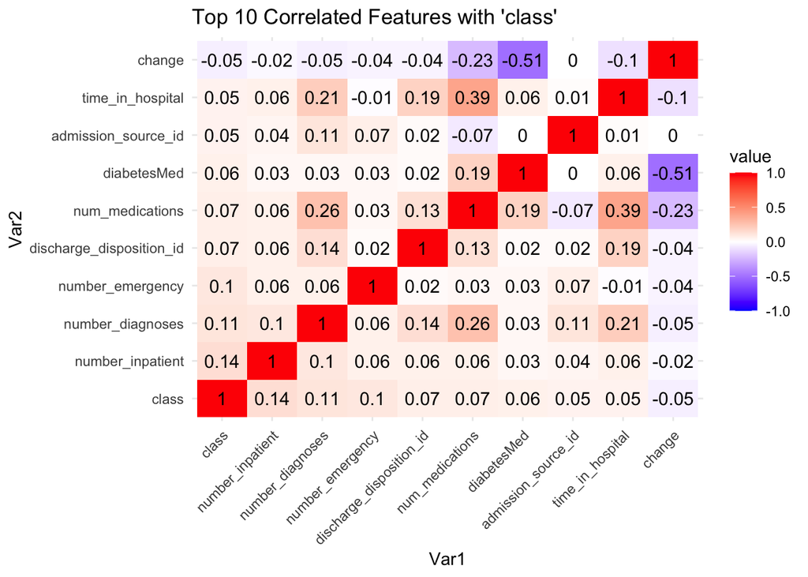

```r
# Get the absolute correlation values of each feature with the target variable "class"
class_correlation <- abs(corr_mat[, "class"])

# Get the names of the top 10 correlated features with "class"
top_features <- names(head(sort(class_correlation, decreasing = TRUE), 10))

# Filter the correlation matrix to include only the top correlated features with "class"
corr_mat_top <- corr_mat[top_features, top_features]

# Melt the correlation matrix
melted_corr_mat_top <- melt(corr_mat_top)

# Plot the correlation heatmap for top correlated features with "class"
ggplot(data = melted_corr_mat_top, aes(x = Var1, y = Var2, fill = value)) +
  geom_tile() +
  geom_text(aes(label = value), color = "black", size = 4) +
  scale_fill_gradient2(low = "blue", mid = "white", high = "red", midpoint = 0,
                       limits = c(-1, 1), na.value = "grey50") +
  theme_minimal() +
  theme(axis.text.x = element_text(angle = 45, hjust = 1)) +
  labs(title = "Top 10 Correlated Features with 'class'")
```

```r
df$class <- ifelse(df$class == 1, 0, df$class)
df$class <- ifelse(df$class == 2, 1, df$class)
unique(df$class)
```

```
## [1] 0 1
```

# Clasification

H0: There is no association between the number of times a patient was admitted to the hospital (number_inpatient) and the risk of readmission. H0: The time spent in the hospital (time_in_hospital) does not affect the risk of readmission.

```r
train_index <- createDataPartition(df$class, p = 0.7, list = FALSE)
train_data <- df[train_index, ]
test_data <- df[-train_index, ]
```

```r
model <- glm(class ~ time_in_hospital + number_inpatient, data = train_data, family = binomial)
summary(model)
```

```
##
## Call:
## glm(formula = class ~ time_in_hospital + number_inpatient, family = binomial,
##     data = train_data)
##
## Coefficients:
##                  Estimate Std. Error z value Pr(>|z|)
## (Intercept)      -0.40632    0.01280  -31.75   <2e-16 ***
## time_in_hospital  0.38275    0.03213   11.91   <2e-16 ***
## number_inpatient  0.93188    0.02569   36.27   <2e-16 ***
## ---
## Signif. codes:  0 '***' 0.001 '**' 0.01 '*' 0.05 '.' 0.1 ' ' 1
##
## (Dispersion parameter for binomial family taken to be 1)
##
##     Null deviance: 94846  on 68636  degrees of freedom
## Residual deviance: 93294  on 68634  degrees of freedom
## AIC: 93300
##
## Number of Fisher Scoring iterations: 4
```

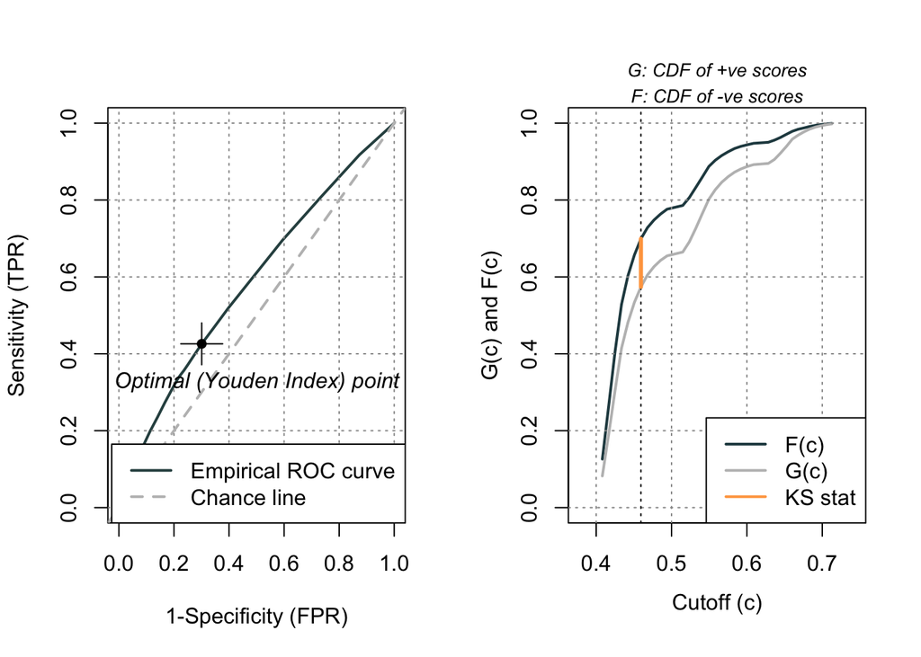

```r
library(ROCit)
roc <- rocit(class = model$y,
             score = model$fitted.values)

par(mfrow = c(1,2))
plot(roc)
ksplot(roc)
```

The ROC curve illustrates the trade-off between sensitivity (true positive rate) and specificity (true negative rate) for different threshold values. It plots the true positive rate (sensitivity) against the false positive rate (1 - specificity). A diagonal line represents random guessing, and a curve above the diagonal indicates better-than-random performance.

The KS plot visualizes the cumulative distribution functions (CDFs) of the positive and negative classes, showing the separation between the two distributions. The Kolmogorov-Smirnov statistic measures the maximum distance between the two CDFs, providing a single summary statistic of the model’s discrimination ability.

```r
summary(roc)
```

```
##
##  Method used: empirical
##  Number of positive(s): 32033
##  Number of negative(s): 36604
##  Area under curve: 0.5838
```

```r
# Generate predictions using your logistic regression model
glm.prediction <- predict(model, newdata = test_data,type = "response")

# Convert predictions to factors (0 or 1) based on a threshold
glm.prediction <- ifelse(glm.prediction >= 0.5, 1, 0)

# Create a confusion matrix
cm0 <- confusionMatrix(factor(glm.prediction), factor(test_data$class))
cm0
```

```
## Confusion Matrix and Statistics
##
##           Reference
## Prediction     0     1
##          0 12403  9105
##          1  3331  4576
##
##                Accuracy : 0.5772
##                  95% CI : (0.5716, 0.5829)
##     No Information Rate : 0.5349
##     P-Value [Acc > NIR] : < 2.2e-16
##
##                   Kappa : 0.1262
##
##  Mcnemar's Test P-Value : < 2.2e-16
##
##             Sensitivity : 0.7883
##             Specificity : 0.3345
##          Pos Pred Value : 0.5767
##          Neg Pred Value : 0.5787
##              Prevalence : 0.5349
##          Detection Rate : 0.4217
##    Detection Prevalence : 0.7312
##       Balanced Accuracy : 0.5614
##
##        'Positive' Class : 0
##
```